# Research into the red-attraction phenomenon.

*N* removed NAs: 2

*N* removed typo: 1

*N* removed <18: 22

*N* total clean: 125

| Group | *N* | *M*<sub>age</sub> | *M*<sub>rating</sub> |
| --- | --- | --- | --- |
| Control | 66 | 21.1 | 5.79 |
| Experim | 59 | 21.0 | 6.11 |

**Main analysis results**

*t*(123) = -2.25, *p* = .026

[interactive chart not shown]

[figure not shown]

[interactive chart not shown]

# Research into the red-attraction phenomenon.

A replication of ‘Red, rank and romance in women viewing men (Elliot et al, 2010)’.

# Methods

## Participants

*Figure.1* Age Descriptive Statistics by experimental condition

| Group | Number of Participants | Percentage | Mean Age | SD age |
| --- | --- | --- | --- | --- |
| white | 66 | 52.8 | 21.1 | 1.96 |
| red | 59 | 47.2 | 21.0 | 1.92 |

This table displays further the breakdown of the spread of the age of participants across the two experimental groups.

## Design

This study is a replication of the study by (Elliot et al, 2010). The aim of this study is to find out whether the colour red will increase women’s perception of male attractiveness. There were three questions on the questionnarire that the participants were required to complete. In the questionnaire participants were asked to rate the man in the photo on a scale from 1 to 9 on measures such as attractiveness, happiness and whether the participant would want to date/ kiss the person in the photo. A high score on this scale represented a greater percieved attractiveness whereas a low score indicated a lack of attraction.

The operational hypothesis is that a red coloured frame on an image will lead to a greater attraction score out of 9 than a neutrally coloured frame (white) on the same image. For my hypothesis testing I will be conducting a t-test to ascertain whether there is a significant difference between the two conditions.

# Results

The results suggest that the neutral white condition achieved lower attraction ratings than the colour red which achieved greater attraction ratings with the means respectively being 5.788, 6.107 for the white condition and red condition. Attraction rating was caluculated by finding the mean rating across the 3 questions in our questionairre then amalgamating these scores into a mean attraction score.

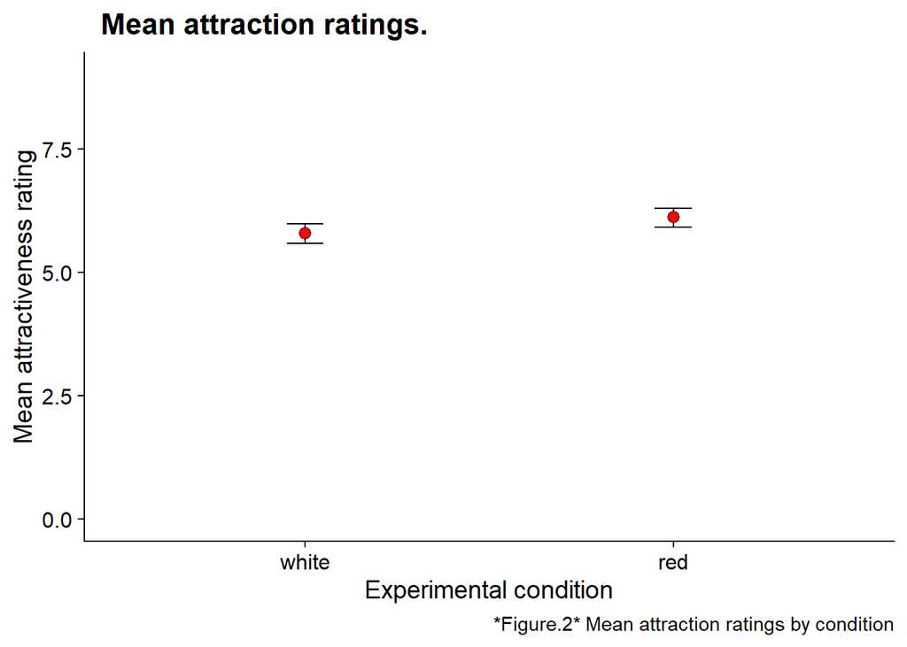

This graph demonstrates the difference in mean attraction rating between the two experimental groups, showing that the red condition has a higher mean attractiveness rating than in the white condition. To look at it alternatively a linear model of this plot found a intercept and slope of 5.788, 0.319 between the two data points, showing in a different format the greater attraction ratings for the red colored frame over the white frame.

*Figure.3* Mean score by group for each question

| Experimental Condition | Question 1 | Question 2 | Question 3 |
| --- | --- | --- | --- |
| white | 5.80 | 5.80 | 5.76 |
| red | 6.22 | 6.12 | 5.98 |

This graph highlights that not only was it found that the color red led to a higher average attractiveness rating overall it also had a higher average attractiveness rating across all of the three questions. This table may suggest that the color red may affect multiple facets that contribute to what we perceive as attractive as the three questions cover multiple aspects of attractiveness.

The results of the statistical testing ( Two Sample t-test) suggest the findings are significant; the t value was found to be -2.248 with a p-value of 0.026 this makes the probability of the findings being insignificant, markedly lower than the standard p<0.05 threshold. This suggests that the findings of this study are significant and that red leads to a greater degree of attraction than a neutral color.

The t test shows that there were 123 degrees of freedom which signifies the amount of information the data can provide when the number of parameters in the data (eg. number of question) and the number of participants are considered suggesting a good amount of variability in our data. The percentage confidence interval of our data was -0.601, -0.038 which conversely to the p-value means we can be 95% confident that this interval captured the true mean attraction rating.

# Discussion

In summary, the findings of this study suggest that the color red does increase women’s perception of male attractiveness in comparison to a neutral color (white). Our study found that participants gave higher ratings of attraction to the photo of the man with the red frame, than the white frame.

These findings support (Elliot et al, 2010) findings that a red frame/background on a photo leads to greater rated attractiveness. This was supported by our t test also revealing a significant color effect between the conditions. However, there was slight variation in aspects such as; our group mean score for red being lower and our group mean score for white being higher than in (Elliot et al, 2010) study. This could suggest red may have less of an effect on attractiveness than the previous study found. However the results indisputably show the same pattern overall as the original red study, suggesting red does have an affect on perceived attractiveness .

The similarity in patterns between the findings of the two studies suggests that not only is the impact of the color red on attractiveness potentially unchanged from 2010 (over a decade ago now) suggesting sustained links to biological/social implications to attractiveness. It also could suggest this effect may exist across a population as the same results have been found with a far larger set of participants than the original study, which contained only 21 women and also with an entirely different set of participants.

These results are supported by studies such as (Prokop,Pazda and Elliot, 2015) who found links between women’s hormonal cycle and an increased attraction to the color red, suggesting similarly that there are significant links between the color red and increased female perceived attraction. A study by (Williams,Schofield & Whitford, 2017) also found that red led to a greater female attraction to men and furthermore found the effects of the color red on attraction to be present when merely viewing the color red prior to the image of the man, suggesting that red truly has an interesting effect on female attraction.

(Elliot and Niesta, 2010)’s study has faced much criticism with (Francis, 2013) suggesting that their findings lack the power to support the claim that red leads to greater levels of attraction. Furthermore multiple replications of the original study have failed to find the red-attractiveness effect. For example (Hesslinger,Goldbach & Carbon,2015) failed to find any significant red-attraction effect for a red frame surrounding a photo.

Additionally studies such as (Williams,Schofield and Whitford, 2017) interestingly failed to find a similar effect with women wearing red, likewise with (Peperkoorn, Craig Roberts and Pollet,2016) so this is an avenue where further research may serve to reveal an explanation for this potential difference in gender perception of the attractiveness associated with the color red.

The variations in findings around the red-attractiveness effect makes our study even more important since we found our result, that red leads to greater attraction, to be significant. Considering that our study had a larger sample with a greater age range than (Elliot and Niesta, 2010)’s study it can be argued the findings have more weight in the red-attraction debate. However it must also be acknowledged that our study utilized far fewer questions in the questionnaire than (Elliot and Niesta, 2010) having used only 3. It may be argued that 3 measures is not sufficient questioning to access something as complex as attraction. A potential further limitation could be the usage of only one male image in our study which it may be argued limits the ecological validity of our study.

I would argue that the extent of study in this area suggests that there is something to the red-attraction effect however, I am concerned that it may not be as clear as our evidence suggests as there seems to be a fair degree of variability involved in the circumstances in which the effect is seen. It seems key that the context may play a large role in how and when the color red is associated with increased female to male attraction

In further research it would be key to use a longer questionnaires to provide a more comprehensive review of attraction and due to the subjectivity of attraction in future research it may be important to use multiple images of different men, with a range of looks to more realistically represent attraction in our diverse society. I suggest this due to (Wen, Zuo & Wu, 2014) finding that men with traditionally ‘masculine’ faces were peeved as more attractive when wearing red. This finding led them to the assumption that this was due to masculinity and red both signalling male status. This suggests in the future that our study should be replicated with a greater variation of male photos, to see if there are any circumstances in which men with non-traditionally masculine features are still considered more attractive with a red background and see if this could perhaps account for the variation in the red-attractiveness effect across findings.

In conclusion this study supports the existence of a red-attraction effect having found a significant relationship between the color red and attractiveness ratings. However, in the future further research is required to attempt to find a cause for the immense variability in red-attraction findings, including between women to men attraction and men to women attraction, the second of which we did not research in our study. Furthermore future research should aim to use longer questionnaires to more comprehensively ascertain a red-attraction effect.

# References

Elliot, A. J., Kayser, D. N., Greitemeyer, T., Lichtenfeld, S., Gramzow, R. H.,Maier, M. A., & Liu, H. (2010). Red, rank, and romance in women viewing men. *Journal of Experimental Psychology. General, 139*(3), 399–417.

Francis, G. (2013). Publication bias in “Red, rank, and romance in women viewing men,” by Elliot et al. (2010). *Journal of Experimental Psychology: General, 142*(1), 292–296.

Hesslinger, V. M., Goldbach, L., & Carbon, C.-C. (2015). Men in red: A reexamination of the red-attractiveness effect. *Psychonomic Bulletin & Review, 22*(4), 1142–1148.

Peperkoorn, L. S., Roberts, S. C., & Pollet, T. V. (2016). Revisiting the Red Effect on Attractiveness and Sexual Receptivity: No Effect of the Color Red on Human Mate Preferences. *Evolutionary Psychology, 14*(4), 1474704916673841.

Prokop, P., Pazda, A. D., & Elliot, A. J. (2015). Influence of conception risk and sociosexuality on female attraction to male red. *Personality and Individual Differences, 87*, 166–170.

Williams, L. A., Schofield, T. P., & Whitford, T. J. (2017). Romantic Red: Testing the Characteristics of Color–Attraction Effects in a Novel Paradigm. Collabra: *Psychology, 3*(1), 10.

Wu, Y., Lu, J., Dijk, E. van, Li, H., & Schnall, S. (2018). The Color Red Is Implicitly Associated With Social Status in the United Kingdom and China. *Frontiers in Psychology, 9*.